# 두경부암(Head & Neck) 임상 코호트 분석

**목표.** 진행 중인 두경부암(Head & Neck) 임상 코호트를 ClinicalTrials.gov 전량 수집 데이터로 분석하여, (1) 표준치료 **B(대조군/backbone)** 데이터 자산을 수요 폭 기준으로 우선순위화하고, (2) **코호트 유사도 2D 맵 + 군집화**로 제약사들이 집중하는 코호트 분포를 시각화한다. 빅파마 참여 임상을 강조 표시해 **먼저 접근할 코호트**를 선별한다.

핵심 통찰: `A + B vs B`(또는 `A vs B`) 구조에서 **B는 표준치료**이며, 스폰서들은 공통적으로 "B 치료에 따른 종양미세환경(TME) 변화·반응 바이오마커"를 원한다 → B의 실제 TME 데이터는 그 B를 쓰는 진행 중 임상이 많을수록 가치가 높다.

```
Head & Neck: industry-led trials 265 / 401 (academic/other excluded)
```

|  | nct_id | brief_title | phase | phase_simple | overall_status | enrollment | lead_sponsor | company | sponsor_scale | is_industry | ... | biomarkers_pipeline | tme_relevant | is_combination | PD-L1_CPS | HPV_p16 | EGFR | MSI-H/dMMR | first_line | later_line | biomarker_selected |
| --- | --- | --- | --- | --- | --- | --- | --- | --- | --- | --- | --- | --- | --- | --- | --- | --- | --- | --- | --- | --- | --- |
| 0 | NCT02568267 | Basket Study of Entrectinib (RXDX-101) for the... | PHASE2 | Phase 2 | ACTIVE_NOT_RECRUITING | 534 | Hoffmann-La Roche | Roche/Genentech | 922 | 1 | ... | ALK;NTRK;ROS1 | 0 | 1 | 0 | 0 | 0 | 0 | 0 | 0 | 0 |
| 1 | NCT02628067 | Study of Pembrolizumab (MK-3475) in Participan... | PHASE2 | Phase 2 | ACTIVE_NOT_RECRUITING | 1609 | Merck Sharp & Dohme LLC | Merck (MSD) | 649 | 1 | ... | CDX;MMR;MSI;MSI-H;PD-L1;TMB;dMMR | 1 | 1 | 1 | 0 | 0 | 1 | 1 | 0 | 1 |
| 2 | NCT03132922 | MAGE-A4ᶜ¹º³²T for Multi-Tumor | PHASE1 | Phase 1 | ACTIVE_NOT_RECRUITING | 71 | USWM CT, LLC | USWM CT | 8 | 1 | ... | HLA-A2;MAGE-A4 | 1 | 1 | 0 | 0 | 0 | 0 | 0 | 0 | 0 |

3 rows × 27 columns

## 1. EDA — 수집 데이터 분포 점검

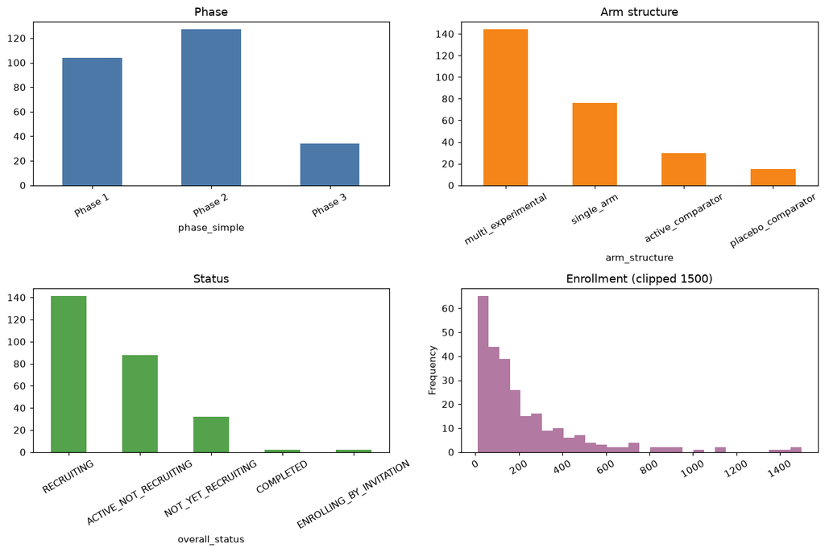

```
Industry-led: 265 | Big pharma involved: 67
TME-relevant modality: 159 | Biomarker-selected eligibility: 130
```

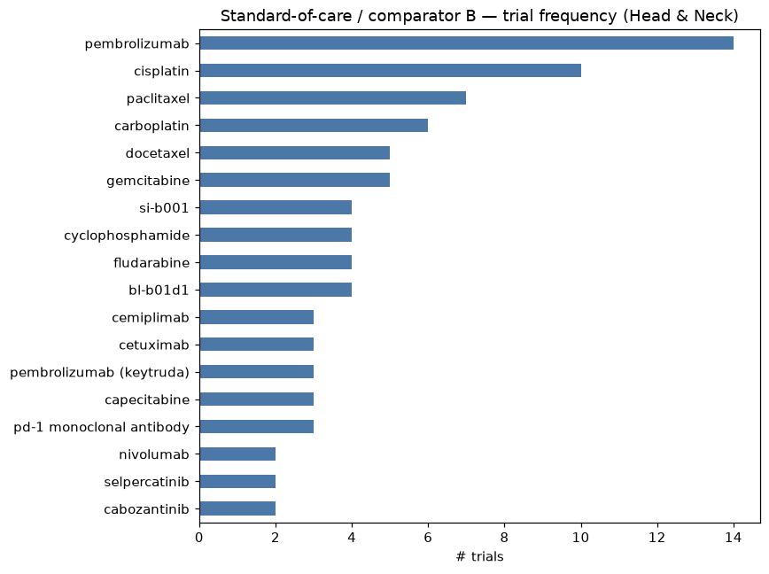

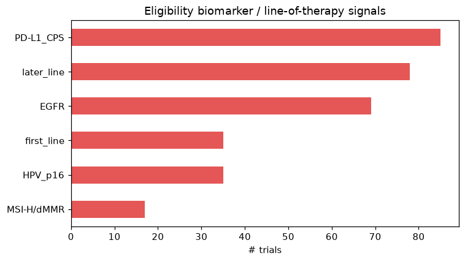

## 1-B. 표준치료(SoC) 대조군 코호트 분류 (정규화 보정 포함)

각 임상의 대조군/backbone을 스캔해 **확립된 표준치료(SoC)가 있는 코호트**와 아닌 것으로 나눈다. 레지멘 변형(`FLOT regimen`), 복합 표기(`trastuzumab + XELOX`), generic 표기(`standard of care`, `investigator's choice`)까지 substring으로 인식해 정규화 누락을 보정한다. 비-SoC는 ① 대조군 없음(단일군/비대조), ② novel 신약만, ③ 비약물(수술·기기·진단)으로 세분한다.

```
cohort_class
novel drug only (no SoC)        189
SoC-anchored                     68
non-drug (surgery/device/dx)      8

SoC-anchored: 68 / 265
```

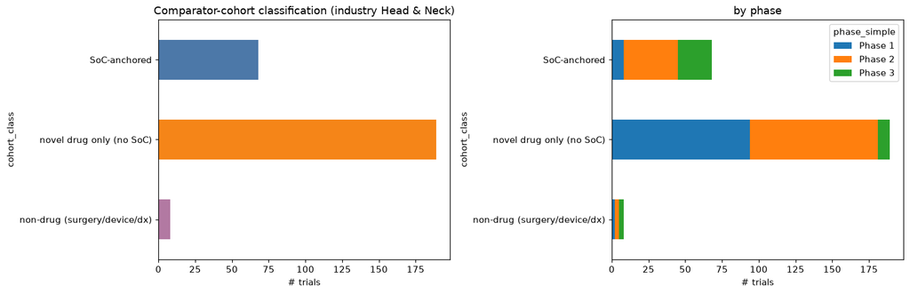

```
SoC-anchored 코호트의 치료 계열 분포:
soc_class
IO                   25
chemo                24
IO;chemo              5
anti_EGFR             4
SoC_generic           3
RET_TKI               2
anti_EGFR;chemo       2
ALK/ROS1_TKI          1
BRAF_MEK              1
SoC_generic;chemo     1
```

## 2. Feature engineering — 표준치료 **성분(component)** 인코딩

**바이오마커·타겟·모달리티·arm 구조 등은 제외.** SoC-anchored 코호트만 남긴다. 군집화 feature는 표준치료를 **성분 약물 수준**으로 인코딩한다(FOLFOX→5FU+leucovorin+oxaliplatin). 이유: 레지멘을 원자 feature로 두면 "3개 중 2개만" 쓴 케이스나 유사 레지멘이 코사인 유사도 0으로 분리되지만, 성분으로 두면 **부분 겹침이 반영**돼 임상적으로 가까운 코호트가 가깝게 위치한다. 레지멘 라벨(`B_soc`)은 클러스터 해석·카드 표시용으로만 유지.

```
standard-of-care anchored cohorts: 68  (from 265 industry Head & Neck trials)
feature matrix (SoC components): (68, 22)
성분 feature: ['B=atezolizumab', 'B=capecitabine', 'B=carboplatin', 'B=cemiplimab', 'B=cetuximab', 'B=cisplatin', 'B=dabrafenib', 'B=docetaxel', 'B=dostarlimab', 'B=durvalumab', 'B=entrectinib', 'B=fluorouracil', 'B=gemcitabine', 'B=methotrexate', 'B=nivolumab', 'B=paclitaxel', 'B=pembrolizumab', 'B=p…
```

## 2-B. 레지멘 수준 데이터 (별도 표시)

군집은 성분 기반이지만, 사람이 읽기 좋은 **레지멘 관점**으로도 따로 집계한다: 각 코호트의 **화학요법 backbone**과 **추가 표적·면역 약물**(+anti-VEGF/+anti-EGFR/+IO/+HER2/+CLDN18.2)을 조합해 분포를 본다.

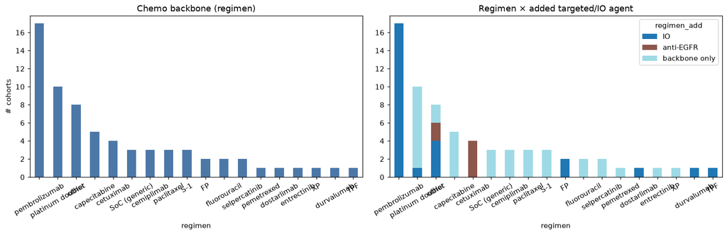

```
레지멘 × 추가약물 교차표:
regimen_add       IO  anti-EGFR  backbone only
regimen
FP                 2          0              0
S-1                0          0              3
SoC (generic)      0          0              3
TPF                1          0              0
XP                 0          0              1
capecitabine       0          0              5
cemiplimab         0          0              3
cetuximab          0          4              0
dostarlimab        1          0              0
durvalumab         1          0              0
entrectinib        0          0              1
fluorouracil       0          0              2
other              4          2              2
paclitaxel         0          0              3
pembrolizumab     17          0              0
pemetrexed         0          0              1
platinum doublet   1          0              9
selpercatinib      0          0              2
```

## 3. 차원축소 & 군집화 — 치료구성 cosine 공간에서 KMeans (silhouette로 k 선택)

```
k=4  silhouette=0.362  sizes=[np.int64(31), np.int64(23), np.int64(8), np.int64(6)]
k=5  silhouette=0.397  sizes=[np.int64(22), np.int64(20), np.int64(14), np.int64(6), np.int64(6)]
k=6  silhouette=0.413  sizes=[np.int64(23), np.int64(20), np.int64(7), np.int64(6), np.int64(6), np.int64(6)]
k=7  silhouette=0.462  sizes=[np.int64(21), np.int64(19), np.int64(7), np.int64(7), np.int64(6), np.int64(5), np.int64(3)]
k=8  silhouette=0.500  sizes=[np.int64(19), np.int64(17), np.int64(7), np.int64(7), np.int64(6), np.int64(5), np.int64(4), np.int64(3)]
chosen k = 8
```

## 4. 클러스터 프로파일링 — 아키타입 명명

|  | cluster | n | top_B | top_target | top_modality | phase_mix | bigpharma | biomarker_sel% |
| --- | --- | --- | --- | --- | --- | --- | --- | --- |
| 0 | 0 | 4 | standard_of_care, cisplatin | EGFR, HPV | Monoclonal Antibody, Oncolytic Virus | Phase 3:3, Phase 2:1 | 0 | 50 |
| 1 | 1 | 19 | pembrolizumab, nivolumab | PD-1, EGFR, PD-L1 | Monoclonal Antibody, Cell Therapy, Small Molecule | Phase 2:10, Phase 3:6, Phase 1:3 | 9 | 84 |
| 2 | 2 | 5 | capecitabine, docetaxel, gemcitabine | EGFR, B7-H3, PD-1 | Monoclonal Antibody, ADC | Phase 3:3, Phase 2:2 | 0 | 40 |
| 3 | 3 | 7 | paclitaxel, carboplatin, docetaxel | PD-1, PI3K, EGFR | Monoclonal Antibody, Small Molecule, Bispecifi... | Phase 2:6, Phase 1:1 | 2 | 71 |
| 4 | 4 | 6 | cetuximab, methotrexate, docetaxel | NKG2A, CDK4/6, EGFR | Monoclonal Antibody, Small Molecule, ADC | Phase 3:4, Phase 2:2 | 2 | 67 |
| 5 | 5 | 3 | cemiplimab | PD-1 | Monoclonal Antibody, Oncolytic Virus | Phase 2:3 | 3 | 100 |
| 6 | 6 | 7 | pembrolizumab, carboplatin, fluorouracil | PD-1, IL-2, HER3 | Monoclonal Antibody, Peptide, ADC | Phase 2:4, Phase 3:2, Phase 1:1 | 4 | 57 |
| 7 | 7 | 17 | cisplatin, gemcitabine, s-1 | PD-1, RET, BRAF | Small Molecule, Monoclonal Antibody, ADC | Phase 2:9, Phase 3:5, Phase 1:3 | 8 | 53 |

## 5. 코호트 유사도 2D 맵 — 클러스터 · Phase · 빅파마 강조

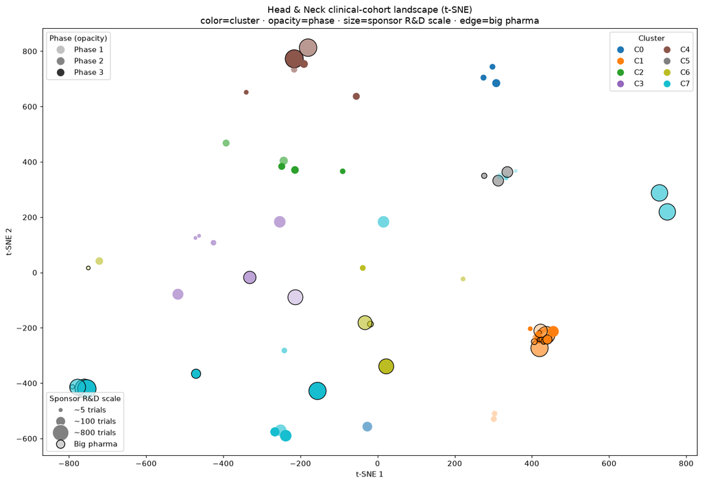

## 5-B. 클러스터별 대표 빅파마 코호트

각 클러스터의 중심(군집 특성공간)에서 **가장 가까운 빅파마 코호트**를 대표로 뽑아 코호트 정의를 정리한다. 대표 제약사·대조군 치료(B)·바이오마커와, 그 클러스터에 함께 속한 다른 제약사들을 표로.

```
saved outputs/cluster_representatives_hnc.csv
```

|  | cluster | n | 대표 제약사 | 대조군 치료 B | 바이오마커 | phase | 대표 NCT | 다른 제약사 |
| --- | --- | --- | --- | --- | --- | --- | --- | --- |
| 0 | 0 | 4 | Rakuten Medical, Inc. (빅파마 없음·최근접) | standard_of_care | - | Phase 3 | NCT03769506 | Merus B.V., ImmunityBio, Inc., CSPC Megalith Biopharmace... |
| 1 | 1 | 19 | Merck Sharp & Dohme LLC | pembrolizumab | PD-L1_CPS, MSI-H/dMMR | Phase 2 | NCT02628067 | Precision Biologics, Inc, Nanobiotix, USWM CT, LLC, BioN... |
| 2 | 2 | 5 | MediLink Therapeutics (Suzhou) Co., Ltd. (빅파마 없음·최근접) | capecitabine;docetaxel;gemcitabine | - | Phase 3 | NCT06629597 | Lepu Biopharma Co., Ltd., CSPC Zhongnuo Pharmaceutical (... |
| 3 | 3 | 7 | Gilead Sciences | carboplatin;paclitaxel | PD-L1_CPS, HPV_p16 | Phase 2 | NCT06727565 | Suzhou Junde Biotechnology Co., Ltd, Sichuan Baili Pharm... |
| 4 | 4 | 6 | AstraZeneca | cetuximab | PD-L1_CPS | Phase 3 | NCT04590963 | Pfizer, Lepu Biopharma Co., Ltd., AVEO Pharmaceuticals, ... |
| 5 | 5 | 3 | Regeneron Pharmaceuticals | cemiplimab | EGFR | Phase 2 | NCT03916627 | Vyriad, Inc. |
| 6 | 6 | 7 | ALX Oncology Inc. | FP;carboplatin;pembrolizumab | PD-L1_CPS | Phase 2 | NCT04675333 | Asher Biotherapeutics, Inc., MediLink Therapeutics (Suzh... |
| 7 | 7 | 17 | Merck Sharp & Dohme LLC | cisplatin | PD-L1_CPS, HPV_p16 | Phase 3 | NCT03765918 | Hoffmann-La Roche, Eli Lilly and Company, NeoTX Therapeu... |

## 5-C. 인터랙티브 코호트 대시보드 (HTML)

`outputs/cohort_map_<slug>.html` — 좌: 코호트 맵, 우: ① 클러스터별 정보, ② **R&D 규모순 제약사 드롭다운** → 선택 시 맵에서 위치 하이라이트 + 그 제약사 임상의 ClinicalTrials.gov 링크·상세 카드. 맵의 점 클릭·hover(제약사·레지멘·Phase·status)도 지원.

```
saved /Users/minsung.choi/clinical_data_finder/outputs/cohort_map_hnc.html
```

## 6. 가치 랭킹 — 표준치료 B 데이터 자산 (수요 폭 중심)

각 B에 대해: **demand_breadth**(그 B를 쓰는 진행 중 트라이얼 수, 주축) + 스폰서 다양성 + 빅파마 수 + phase 가중 + 등록 규모 + TME 관련성 + 바이오마커 개방성.

|  | B (standard therapy) | demand_breadth | sponsors | bigpharma | phase_weight | n_phase3 | enroll_sum | tme_rel% | biomarker% | value_score |
| --- | --- | --- | --- | --- | --- | --- | --- | --- | --- | --- |
| 0 | pembrolizumab | 24 | 21 | 12 | 47.8 | 8 | 7678 | 75 | 83 | 0.982400 |
| 1 | cisplatin | 8 | 7 | 3 | 17.8 | 4 | 2118 | 62 | 88 | 0.346275 |
| 2 | carboplatin | 7 | 7 | 5 | 13.4 | 2 | 1548 | 86 | 86 | 0.339186 |
| 3 | paclitaxel | 8 | 8 | 2 | 13.6 | 1 | 964 | 50 | 75 | 0.308555 |
| 4 | cetuximab | 6 | 6 | 2 | 15.2 | 4 | 1336 | 83 | 67 | 0.276831 |
| 5 | docetaxel | 6 | 5 | 0 | 13.8 | 3 | 1539 | 83 | 50 | 0.242500 |
| 6 | gemcitabine | 6 | 5 | 0 | 15.2 | 4 | 1755 | 67 | 50 | 0.240764 |
| 7 | capecitabine | 5 | 4 | 0 | 12.2 | 3 | 1734 | 80 | 40 | 0.207365 |
| 8 | standard_of_care | 4 | 4 | 0 | 10.6 | 3 | 1166 | 75 | 50 | 0.176153 |
| 9 | cemiplimab | 3 | 2 | 3 | 4.8 | 0 | 272 | 100 | 100 | 0.157138 |
| 10 | nivolumab | 3 | 3 | 1 | 5.0 | 1 | 5265 | 33 | 0 | 0.130929 |
| 11 | fluorouracil | 3 | 3 | 1 | 4.2 | 0 | 912 | 67 | 33 | 0.126362 |
| 12 | pemetrexed | 2 | 2 | 0 | 3.2 | 0 | 800 | 100 | 100 | 0.119917 |
| 13 | FP | 2 | 2 | 2 | 3.2 | 0 | 322 | 100 | 50 | 0.109816 |
| 14 | s-1 | 3 | 3 | 0 | 3.6 | 0 | 361 | 67 | 67 | 0.109432 |

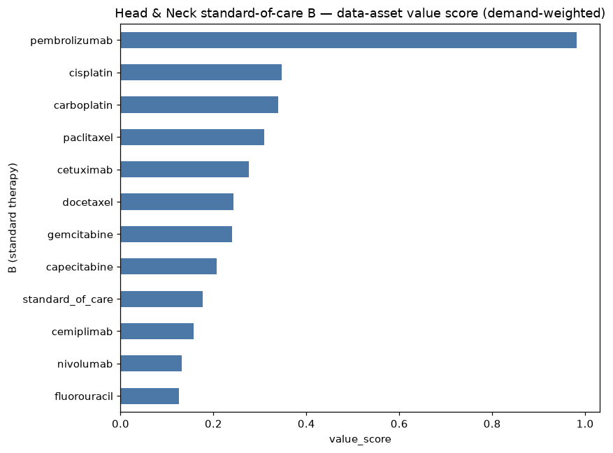

## 7. 먼저 접근할 코호트 — 빅파마 참여 + Phase 3 우선

|  | nct_id | phase_simple | lead_sponsor | B_soc | targets | enrollment | arm_structure | biomarker_selected |
| --- | --- | --- | --- | --- | --- | --- | --- | --- |
| 59 | NCT07620574 | Phase 3 | Exelixis | atezolizumab;nivolumab | MET | 5000 | single_arm | 0 |
| 5 | NCT03765918 | Phase 3 | Merck Sharp & Dohme LLC | cisplatin | PD-1 | 714 | active_comparator | 1 |
| 38 | NCT06082167 | Phase 3 | Exelixis | pembrolizumab | EGFR | 600 | placebo_comparator | 1 |
| 58 | NCT07276399 | Phase 3 | Janssen Research & Development, LLC | carboplatin;cisplatin;pembrolizumab | EGFR | 500 | active_comparator | 1 |
| 14 | NCT04590963 | Phase 3 | AstraZeneca | cetuximab | NKG2A | 370 | active_comparator | 1 |
| 18 | NCT04940052 | Phase 3 | Novartis Pharmaceuticals | dabrafenib;trametinib | BRAF | 153 | placebo_comparator | 0 |
| 1 | NCT02628067 | Phase 2 | Merck Sharp & Dohme LLC | pembrolizumab | PD-1 | 1609 | multi_experimental | 1 |
| 0 | NCT02568267 | Phase 2 | Hoffmann-La Roche | entrectinib | ROS1 | 534 | multi_experimental | 0 |
| 36 | NCT06062420 | Phase 2 | GlaxoSmithKline | dostarlimab | PD-1 | 316 | multi_experimental | 1 |
| 15 | NCT04675294 | Phase 2 | ALX Oncology Inc. | pembrolizumab | PD-1 | 189 | active_comparator | 1 |
| 16 | NCT04675333 | Phase 2 | ALX Oncology Inc. | FP;carboplatin;pembrolizumab | PD-1 | 172 | active_comparator | 1 |
| 2 | NCT03284424 | Phase 2 | Merck Sharp & Dohme LLC | pembrolizumab | PD-1 | 159 | multi_experimental | 1 |
| 61 | NCT07744126 | Phase 2 | AbbVie | FP;carboplatin;pembrolizumab | PD-1 | 150 | active_comparator | 0 |
| 32 | NCT05784688 | Phase 2 | TiumBio Co., Ltd. | pembrolizumab | TGFBR1 | 140 | multi_experimental | 1 |
| 50 | NCT06769698 | Phase 2 | Regeneron Pharmaceuticals | cemiplimab | PD-1 | 120 | multi_experimental | 1 |
| 20 | NCT05086692 | Phase 2 | Medicenna Therapeutics, Inc. | pembrolizumab | IL-2 | 115 | single_arm | 0 |
| 35 | NCT06016920 | Phase 2 | Nykode Therapeutics ASA | pembrolizumab | HPV16 | 110 | multi_experimental | 1 |
| 12 | NCT04291105 | Phase 2 | Vyriad, Inc. | cemiplimab | NaN | 87 | multi_experimental | 1 |
| 11 | NCT04280081 | Phase 2 | Eli Lilly and Company | selpercatinib | RET | 77 | single_arm | 0 |
| 8 | NCT03916627 | Phase 2 | Regeneron Pharmaceuticals | cemiplimab | PD-1 | 65 | multi_experimental | 1 |

## 8. 요약

- **가치 랭킹(`outputs/value_ranking_hnc.csv`)**: 두경부암(Head & Neck)에서 TME 데이터를 만들면 가장 많은 스폰서가 원할 표준치료 B 순위.
- **코호트 맵/대시보드(`outputs/cohort_map_hnc.png` / `.html`)**: 제약사들이 집중하는 코호트 아키타입 분포, Phase·빅파마 강조.
- **먼저 접근할 코호트**: 빅파마 참여 + Phase 3 pivotal 우선.